# Control de Calidad

Para llevar a cabo actividades de control de calidad, es importante comprender qué es la **calidad**, su importancia y, además, la relación entre los **clientes** y la calidad.

- Comprensión y explicación de la calidad, su importancia y **el concepto de priorizar la calidad**.
- Comprensión y explicación de la visión general de **la gestión de la calidad**.
- Comprensión y explicación de **la satisfacción del cliente** y la calidad objetivo.
- Comprensión y explicación de los **problemas** y los **desafíos**.
- Comprensión y explicación de las **quejas** y **reclamaciones**.

[Audio_1](https://drive.google.com/file/d/1zGCZelXKPFVjPp6QeAieoYhwSzDRZqI5/view?usp=drive_link)

```python
import os

try:
  os.chdir('../Python/QCKentei4')
except:
  pass

path = os.getcwd()
path
```

```
'/Users/takanohiroshi/Library/CloudStorage/OneDrive-個人用/Documenten/Python/QCKentei4'
```

```python
def ensure_and_move_to_folder(folder_name):
  current_dir = os.getcwd()
  target_path = os.path.join(current_dir, folder_name)

  if not os.path.exists(target_path):
    os.makedirs(target_path)
    print(f"Folder '{folder_name}' created successfully.")
  else:
    print(f"Folder '{folder_name}' already exists.")

  #os.chdir(target_path)
```

```python
folder_name = 'Data4'
ensure_and_move_to_folder(folder_name)
```

```
Folder 'Data4' already exists.
```

```python
from IPython.display import display
from PIL import Image
```

## 01-01 La calidad y su importancia

品質とその重要性

### 1. ¿Qué es la calidad?

La **calidad**（品質） se refiere generalmente a la calidad de los productos o servicios. Es el grado en que las características inherentes (función, rendimiento, operatividad, etc.) de estos productos o servicios satisfacen las necesidades de las personas que los utilizan (los clientes).

Si desglosamos la estructura de la **calidad de un producto**（製品品質）, podemos dividir la en las siguientes categorías: **utilidad**, **seguridad**, **espacio (forma, tamaño, peso)**, **tiempo (tasa de funcionamiento)** y **economía**. Cada una de estas categorías se subdivide a su vez en elementos de calidad más específicos.

- **Utilidad**, （有用性） Usabilidad: es la cualidad de un producto que lo hace útil para el cliente. La utilidad se compone de las funciones del productos, su rendimiento, su facilidad de uso y sus propiedades psicológicas (sensaciones y emociones como que la apariencia sea atractiva, el sonido sea agradable o que su uso proporciones tranquilidad).
- **Seguridad**: （安全性） es la característica de un producto que evalúa en qué medida se minimiza el riesgo de que cause algún tipo de daño al usarlo. Esto incluye no solo el daño para las personas que usan el producto, sino también el daño para la sociedad y el medio ambiente.
- **Espacio (forma, tamaño, peso)**: （空間：形・大きさ・重さ） es la característica de un producto que se refiere al espacio que ocupa.
- Tiempo, **Tasa de funcionamiento** / Tiempo, índice de operatividad: （時間・稼働率） se refiere al grado o la capacidad de un producto para funcionar de manera continua. Esto incluye la capacidad de ser utilizado sin fallar durante un periodo de tiempo determinado y la facilidad de reparación (mantenibilidad).
- **Economía**, Rentabilidad: （経済性） se refiere a los costos asociados con el uso y la eliminación del producto.

### 2. La importancia de la calidad

品質の重要性

La actividad empresarial se basa en lo siguiente: las empresas ofrecen productos y servicios a los clientes, utilizan las ganancias para obtener los fondos necesarios para operar, y luego desarrollan nuevos productos y servicios para seguir contribuyendo a la sociedad.

Si la empresa no logra que los clientes compren los productos y servicios que ha desarrollado, su gestión empresarial no será sostenible y, por lo tanto, no podrá seguir contribuyendo a la sociedad. Por lo tanto, es fundamental que las empresas continúen creando productos y servicios para que los clientes se sientan satisfechos de comprar. Para lograrlo, las empresas deben investigar y comprender a fondo las necesidades de los clientes, establecer las especificaciones deseadas para los productos y servicios, llevar a cabo eficientemente la investigación y el desarrollo de las tecnologías necesarias, e introducir los productos y servicios en el mercado. Además, es necesario observar la reacción del mercado y mejorar continuamente los productos y servicios para crear una calidad aún mejor.

De esta manera, **la gestión de la calidad**（品質管理） es indispensable para crar productos y servicios de mejor calidad.

[Audio_2](https://drive.google.com/file/d/1cmNjg4VlByiFXjuwQJvmD2EzUqmobLik/view?usp=drive_link)

## 01-02 El enfoque de prioridad en la calidad

品質優先の考え方

### 1. Market in / Product out

**Market In** es un concepto que se basa en la idea de entrar en el mercado y conocer las necesidades de los clientes para, posteriormente, desarrollar, fabricar y vender productos y servicios que las satisfagan.

Por otro lado, **Product Out** es el término para la idea de vender a los clientes productos y servicios que se han creado desde el punto de vista del productor.

### 2. QCD

A la hora de desarrollar y gestionar productos y servicios de calidad que satisfagan a los clientes, es importante no solo considerar la **calidad** (Quality) del producto o servicios en sí mismo, sino también tener en cuenta el **costo** (Cost) de su producción y la **cantidad y el plazo de entrega** (Delivery).

Además, al combinar la filosofía de dar prioridad a la calidad (Quality), el costo (Cost) y el plazo de entrega (Delivery), con la filosofía de dar prioridad a la seguridad (Safety), se le conoce como **SQCD**.

### 3. El enfoque de prioridad en la calidad

Para que una empresa pueda ofrecer productos y servicios de alta calidad, es fundamental que todas las personas involucradas adoptan **la mentalidad de dar prioridad a la calidad**. Esto significa que nunca se debe sacrificar la calidad por las ventas o las ganancias a corto plazo, sino que siempre se debe dar prioridad a ofrecer a los clientes productos y servicios de la mejor calidad posible.

[Audio_3](https://drive.google.com/file/d/1LsDO39TNOhA9YxwBpw01IjgwIcT-_xK-/view?usp=drive_link)

## 01-03 ¿Qué es el Control de Calidad?

品質管理とは

### 1. ¿Qué es el Control de calidad?

El **Control de Calidad** es el conjunto de actividades sistemáticas que una empresa lleva a cabo de forma organizada para poder ofrecer productos y servicios con una calidad que satisfaga a los clientes, en el momento y al precio adecuados.

Como en los productos y servicios que se ofrecen a los clientes siempre hay **variaciones**, es necesario minimizar dichas variaciones para evitar la insatisfacción del cliente y gestionar la calidad para que sea la mejor tanto para los clientes como para la empresa. La actividad que gestiona la calidad de los productos y servicios se denomina **gestión de la calidad**.

### 2. Actividades de Control de Calidad

品質管理活動とは

Se dice que la causa de los defectos y la variación de la calidad de un producto se debe principalmente a cuatro elementos: las **personas** (Man) que lo fabrican y lo manipulan; las **máquinas** e instalaciones (Machine) que lo fabrican y transportan; los **componentes y materiales** (Material) que lo componen; y los **métodos** (Method) de fabricación y manipulación.

Estos cuatro elementos se conocen como las **4M** (por sus siglas en inglés: Man, Machine, Material, Method). Al entender y gestionar adecuadamente las 4M, es posible eliminar los defectos de calidad y minimizar las variaciones.

**TQM (Total Quality Management)**

[Audio_4](https://drive.google.com/file/d/1cZuzv72U74_FKur1H62CdmIN3KHS9j_a/view?usp=drive_link)

```
Los cuatro factores que causan la variabilidad de la calidad
```

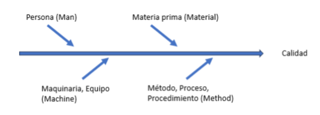

```python
print("Los cuatro factores que causan la variabilidad de la calidad")
img = Image.open('./Data4/4M.png')
display(img)
```

## 01-04 Satisfacción del cliente y Calidad esperada

お客様満足とねらいの品質

### 1. Satisfacción del cliente

お客様満足

**CS** (Customer Satisfaction): se refiere al grado en que las expectativas previas, las necesidades latentes o manifiestas, o los requisitos del cliente, son satisfechos por la utilidad del producto o servicio ofrecido.

Para crear productos y servicios que satisfagan al cliente, es fundamental determinar quién es el cliente y qué tipo de producto o servicio se le va a ofrecer.

En general, al cliente se llama consumidor y la satisfacción del cliente también se le puede llamar satisfacción del consumidor (**CS** por sus siglas en inglés **Customer Satisfaction**（顧客満足）).

Además, al grado de satisfacción del cliente se le llama **índice de satisfacción del cliente**（顧客満足度）.

Dentro de la gestión de la calidad, para mejorarla, también es necesario investigar la satisfacción del cliente a través de encuestas. A esta investigación se le llama **encuesta de satisfacción del cliente**（顧客満足度調査）.

Además, en las actividades de gestión de calidad de una empresa, es importante el concepto de que **el siguiente proceso es el cliente**（後工程はお客様）. Esta es la idea de considerar y valorar el proceso posterior al propio trabajo como si fuera un cliente, para así evitar que los resultados del propio trabajo causen problemas a los departamentos que dependen de él.

### 2. Calidad esperada / Calidad objetivo / Calidad deseada

ねらいの品質

Es importante investigar los requisitos que tienen los clientes sobre un producto o servicio. Hay que recopilar y analizar las exigencias, expectativas y, en algunos casos, los problemas o inconvenientes de los clientes con respecto al producto o servicio. A esto se llama escuchar la **Vos del Cliente (VOC)**.

Establecer la forma ideal o deseada de un producto se conoce como definir la **calidad prevista**（ねらいの品質）. La calidad prevista también se denomina **calidad de diseño**（設計品質） y se refiere a los objetivos de calidad para las características del producto.

[Audio_5](https://drive.google.com/file/d/1XhOzpxPIqRXaoliX8qmILXfv5csTeGTC/view?usp=drive_link)

## 01-05 Problemas y Desafíos

問題と課題

Un **problema** se refiere a la diferencia (brecha) entre el estado ideal (la situación deseada) y el estado actual.

Un **desafio** (o tarea pendiente) se refiere a la diferencia (brecha) entre el estado futuro deseado (la situación ideal a la que se aspira) y el estado actual.

[Audio_6](https://drive.google.com/file/d/15Mre53-Bsc-XbtIGvJktS0xM0IVkbRoH/view?usp=drive_link)

```
Problema y Desafio
```

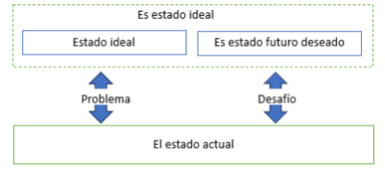

```python
print("Problema y Desafio")
img = Image.open('./Data4/Problema_Desafio.png')
display(img)
```

## 01-06 Quejas / Reclamaciones

苦情・クレーム

Una **queja** (o reclamación) es la insatisfacción que un cliente siente con respecto a un producto o servicio, debido a defectos o deficiencias, entre otros motivos.

Además, entre esasa quejas, aquellas en las que el cliente realiza una solicitud específica como reparación, reemplazo, descuento, reembolso, cancelación de contrato o compensación por daños, se denominan **reclamaciones**

Es imperativo actuar de inmediato para eliminar la insatisfacción del los clientes que han expresado una queja.

Además, se deben recopilar y analizar las quejas de otros clientes para evitar que se sientan insatisfechos de la misma manera. También es necesario llevar a cabo actividades para **prevenir la recurrencia del problema**.

El tratamiento adecuado de las quejas de los consumidores se conoce como **gestión de quejas**.

Dentro de la gestión de quejas, el tratamiento de las reclamaciones de los clientes, como las reparaciones y sustituciones gratuitas, los descuentos, los reembolsos, las rescisiones de contratos y la compensación por daños, se conoce como **gestión de reclamaciones**.

[Audio_7](https://drive.google.com/file/d/11yWuDlGfIYni2T4p93u_fXKhH99X7CXo/view?usp=drive_link)

```python
import pandas as pd
import numpy as np
import polars as pl
import gspread
from google.oauth2.service_account import Credentials

# 認証情報の設定
SERVICE_ACCOUNT_FILE = "my-project-vscode-452201-249bdb033f8c.json"  # JSONファイルのパス
SCOPES = ["https://www.googleapis.com/auth/spreadsheets"]

credentials = Credentials.from_service_account_file(SERVICE_ACCOUNT_FILE, scopes=SCOPES)
client = gspread.authorize(credentials)

# スプレッドシートを開く（URLまたはスプレッドシートIDを使用）
SPREADSHEET_ID = "1RkO0VL4WR6cbPBfBEjz693Lo4SdUAoSvRHV491ggXTo"

sheet = client.open_by_key(SPREADSHEET_ID).worksheet("Sheet6") # 最初のシートを取得

# データを取得
list_of_lists = sheet.get_all_values()

cols = len(list_of_lists[0])
columns = np.arange(1,cols)

index = [row[0] for row in list_of_lists[1:]]
values = [row[1:] for row in list_of_lists[1:]]

df = pd.DataFrame(values, index=index, columns=columns)

df.index_name = list_of_lists[0][0]
df = df.replace(r'^\s*$', np.nan, regex=True)
df = df.astype('float')
df
```

|  | 1 | 2 | 3 | 4 | 5 | 6 | 7 | 8 | 9 |
| --- | --- | --- | --- | --- | --- | --- | --- | --- | --- |
| A | 60.0 | 50.0 | 51.0 | 42.0 | 55.0 | 46.0 | 49.0 | 52.0 | 43.0 |
| B | 40.0 | 76.0 | 48.0 | 64.0 | 59.0 | 63.0 | 73.0 | 56.0 | NaN |

```python
# NumPy 配列に変換（object型）
arr = np.array(list_of_lists, dtype=object)

# ブランク（空文字・空白）を np.nan に置換
arr_cleaned = np.array([[np.nan if str(cell).strip() == '' else cell for cell in row] for row in arr], dtype=object)

# 1列目をカラム名にする（縦方向）
column_names = arr_cleaned[:, 0].tolist()  # ['樹脂材料', 'A', 'B']

# 残りの部分をデータ行にする（縦列 → 横行に転置）
data_values = arr_cleaned[:, 1:]  # (3行 x 9列)
data_rows = data_values.T.tolist()  # (9行 x 3列)

# Polars データフレーム化
df = pl.DataFrame(data_rows, schema=column_names)

# A列とB列を float に変換（NaNも扱えるように strict=False）
df = df.with_columns([
    pl.col("A").cast(pl.Float64, strict=False),
    pl.col("B").cast(pl.Float64, strict=False)
])

print(df)
```

```
shape: (9, 3)
┌──────────┬──────┬──────┐
│ 樹脂材料 ┆ A    ┆ B    │
│ ---      ┆ ---  ┆ ---  │
│ f64      ┆ f64  ┆ f64  │
╞══════════╪══════╪══════╡
│ NaN      ┆ 60.0 ┆ 40.0 │
│ NaN      ┆ 50.0 ┆ 76.0 │
│ NaN      ┆ 51.0 ┆ 48.0 │
│ NaN      ┆ 42.0 ┆ 64.0 │
│ NaN      ┆ 55.0 ┆ 59.0 │
│ NaN      ┆ 46.0 ┆ 63.0 │
│ NaN      ┆ 49.0 ┆ 73.0 │
│ NaN      ┆ 52.0 ┆ 56.0 │
│ NaN      ┆ 43.0 ┆ NaN  │
└──────────┴──────┴──────┘
```

```python
notebook_name = 'QCKentei4-1.ipynb'
notebook_name_html = notebook_name.replace(".ipynb",".html")

!jupyter nbconvert --to html {notebook_name}
```

```
[NbConvertApp] Converting notebook QCKentei4-1.ipynb to html
[NbConvertApp] Writing 771551 bytes to QCKentei4-1.html
```

```python
from IPython.display import display
from PIL import Image
import gdown
import re

def get_file_id(url,out):
    # 正規表現でファイルIDを抽出
    match = re.search(r'/d/([a-zA-Z0-9_-]+)', url)

    if match:
        file_id = match.group(1)
        print("ファイルID:", file_id)
    else:
        print("ファイルIDが見つかりませんでした。")

    url = f"https://drive.google.com/uc?id={file_id}"

    output = out

    gdown.download(url, output, quiet=False)

    img = Image.open(out)
    display(img)
```

[output not shown]

[output not shown]

[figure not shown]

```python
url= 'https://drive.google.com/file/d/1X_EqMhvlS0Y4ei_N12qhtqvp5fw0qgRZ/view?usp=drive_link'
out = './Data4/4M.png'
#get_file_id(url,out)
```

[output not shown]

[output not shown]

[figure not shown]

```python
url= 'https://drive.google.com/file/d/1xCf39Su3abGxobFacIbuXGnkvWwi9EcX/view?usp=drive_link'
out = './Data4/Problema_Desafio.png'
#get_file_id(url,out)
```